# R Notebook

```r
library(reshape)
library(dplyr)
library(ggplot2)
library(lme4)
library(lmerTest)
library(tidyr)
library(plotrix)
```

```r
metadata <- read.csv(file = "GH_2018_metadata_V3.csv", header = T)
metadata <- subset(metadata, Tuber_Mass != "NA")

metadata2 <- metadata %>%
  group_by(Genotype,Soil_type,Selection,Iteration) %>%
  summarise(avg = mean(Tuber_Mass), n=n(), se = std.error(Tuber_Mass))
metadata2 = unite(metadata2, combo_line, c("Genotype","Soil_type","Selection"), remove = F)
```

```r
ggplot(metadata2)+
  aes(x = Iteration, y = avg, color = as.factor(Genotype), group = combo_line)+
  scale_x_discrete(name = "Iteration")+
  scale_y_continuous(name = "Average Tubermass")+
   geom_point(aes(shape=as.factor(Soil_type)), size=3)+
    geom_errorbar(aes(ymax=avg+se, ymin=avg-se), width=.1)+
  geom_line()+
  theme_classic()+
  theme(axis.title.x = element_text(face="bold", size=15))+
  theme(axis.title.y = element_text(face="bold", size=15))
```

[output not shown]

Too messy…so we can subdivide into Clades..

##Chiletanum

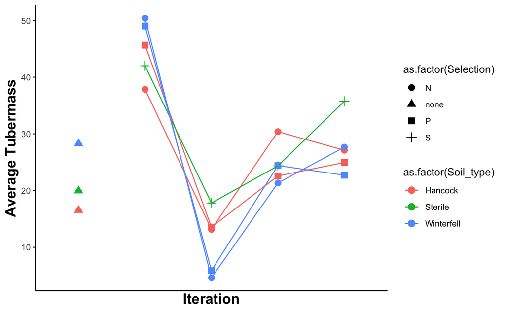

```r
metadata_C <- subset(metadata, Tuber_Mass != "NA" & Clade == "C")

metadata2 <- metadata_C %>%
  group_by(Clade,Soil_type,Selection,Iteration) %>%
  summarise(avg = mean(Tuber_Mass), n=n(), se = std.error(Tuber_Mass))
metadata2 = unite(metadata2, combo_line, c("Clade","Soil_type","Selection"), remove = F)

ggplot(metadata2)+
  aes(x = Iteration, y = avg, color = as.factor(Soil_type), group = combo_line)+
  scale_x_discrete(name = "Iteration")+
  scale_y_continuous(name = "Average Tubermass")+
   geom_point(aes(shape=as.factor(Selection)), size=3)+
    geom_errorbar(aes(ymax=avg, ymin=avg), width=.1)+
  geom_line()+
  theme_classic()+
  theme(axis.title.x = element_text(face="bold", size=15))+
  theme(axis.title.y = element_text(face="bold", size=15))
```

##Andigenum

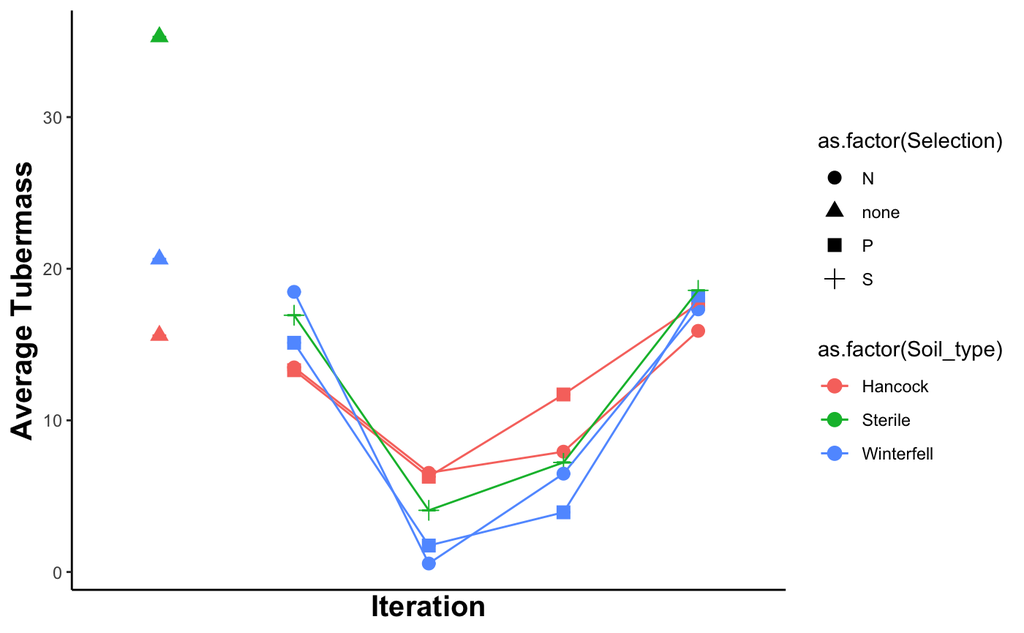

```r
metadata_A <- subset(metadata, Tuber_Mass != "NA" & Clade == "A")

metadata2 <- metadata_A %>%
  group_by(Clade,Soil_type,Selection,Iteration) %>%
  summarise(avg = mean(Tuber_Mass), n=n(), se = std.error(Tuber_Mass))
metadata2 = unite(metadata2, combo_line, c("Clade","Soil_type","Selection"), remove = F)

ggplot(metadata2)+
  aes(x = Iteration, y = avg, color = as.factor(Soil_type), group = combo_line)+
  scale_x_discrete(name = "Iteration")+
  scale_y_continuous(name = "Average Tubermass")+
   geom_point(aes(shape=as.factor(Selection)), size=3)+
    geom_errorbar(aes(ymax=avg, ymin=avg), width=.1)+
  geom_line()+
  theme_classic()+
  theme(axis.title.x = element_text(face="bold", size=15))+
  theme(axis.title.y = element_text(face="bold", size=15))
```

##Modern

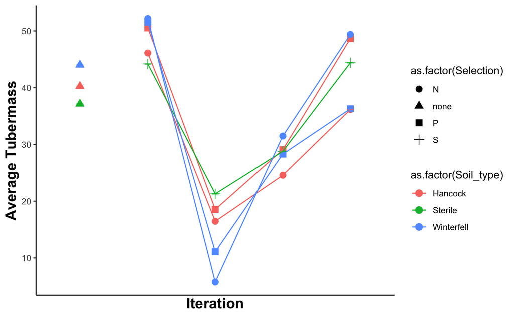

```r
metadata_M <- subset(metadata, Tuber_Mass != "NA" & Clade == "M")

metadata2 <- metadata_M %>%
  group_by(Clade,Soil_type,Selection,Iteration) %>%
  summarise(avg = mean(Tuber_Mass), n=n(), se = std.error(Tuber_Mass))
metadata2 = unite(metadata2, combo_line, c("Clade","Soil_type","Selection"), remove = F)

ggplot(metadata2)+
  aes(x = Iteration, y = avg, color = as.factor(Soil_type), group = combo_line)+
  scale_x_discrete(name = "Iteration")+
  scale_y_continuous(name = "Average Tubermass")+
   geom_point(aes(shape=as.factor(Selection)), size=3)+
    geom_errorbar(aes(ymax=avg, ymin=avg), width=.1)+
  geom_line()+
  theme_classic()+
  theme(axis.title.x = element_text(face="bold", size=15))+
  theme(axis.title.y = element_text(face="bold", size=15))
```

#Modeling:

##Iteration 5

```r
#Model 1: Clade is considered crossed and randomized throughout the greenhouse and genotype is nested within Block and Clade

#Hypothesis: Iteration 5 we see a selection, soil type , and Clade effect on tuber mass

it_5 <- lmer(Tuber_Mass ~ Clade * Soil_type * Selection + (1|Clade:Genotype) + (1|Genotype:Block), data = subset(metadata, Iteration == 5))

anova(it_5)

Tuber_mod <- lmer(Tuber_Mass ~ Soil_type * Selection + (1|Clade:Genotype) + (1|Genotype:Block), data = subset(metadata, Iteration == 5 & Clade == "M"))

anova(Tuber_mod)

Tuber_mod <- lmer(Tuber_Mass ~ Soil_type * Selection + (1|Clade:Genotype) + (1|Genotype:Block), data = subset(metadata, Iteration == 3 & Clade == "M"))

anova(Tuber_mod)
```

```r
metadata2 = subset(metadata, Iteration == 5 & Soil_inoculation != "none" & Tuber_Mass != "NA")

it_5 <- lmer(Tuber_Mass ~ Clade * Soil_type * Selection + (1|Clade:Genotype) + (1|Genotype:Block), data = metadata2)

anova(it_5)
```

*Responsiveness to microbes*:

```r
metadata3 = subset(metadata, Iteration == 5 & Soil_inoculation != "none" & Tuber_Mass != "NA")
```

##Iternation 1:

```r
metadata2 = subset(metadata, Iteration == 1 & Soil_inoculation != "none" & Tuber_Mass != "NA")

it_1 <- lmer(Tuber_Mass ~ Clade * Soil_type + (1|Clade:Genotype) + (1|Block), data = metadata2)

anova(it_1)
```

##Iteration 3

```r
metadata2 = subset(metadata, Iteration == 3 & Soil_inoculation != "none" & Tuber_Mass != "NA")

it_3 <- lmer(Tuber_Mass ~ Clade * Soil_type * Selection + (1|Clade:Genotype) + (1|Block), data = metadata2)

anova(it_3)
```

So we don’t see a Clade effect on tuber yield in absolute terms. how about looking at response with respect to sterile pots (aka our control?)

##Analysis of plant response:

```r
metadata2 <- metadata %>%
  group_by(Clade,Genotype,Soil_type,Selection,Iteration) %>%
  summarise(avg = mean(Tuber_Mass), n=n(), se = std.error(Tuber_Mass))

metadata2 <- metadata %>%
  group_by(Clade,Genotype,Soil_type,Selection,Iteration) %>%
  summarise(avg_bio = mean(Tuber_Mass), n=n(), se = std.error(Tuber_Mass))

#make new column(s) calculated based on plant response:
metadata3 <- subset(metadata2, Soil_type == "Sterile" & avg != "NA")

metadata3 <- left_join(metadata,metadata3,by = c("Genotype","Iteration"))
#metadata3 <- select(metadata3,one_of("Genotype","Iteration","Soil_type.x","Selection.x","avg.x","n.x","se.x","avg.y"))
metadata3 <- mutate(metadata3, Response = Tuber_Mass - avg)
write.csv(metadata3,"metadata3.csv")
```

*First Question*: Is there a Clade effect on microbial response?

```r
metadata3 <- subset(metadata3, Response != "NA" & Soil_type.x != "Sterile")
Res_mod <- lmer(Response ~ Clade * Selection.x * Iteration * Soil_type.x+ (1|Genotype) + (1|Block), data = metadata3)
```

```
fixed-effect model matrix is rank deficient so dropping 16 columns / coefficients
boundary (singular) fit: see ?isSingular
```

```r
anova(Res_mod)
```

```
Missing cells for: Clade:Selection.xN, Clade:Selection.xP, Clade:Selection.xN:Iteration, Clade:Selection.xP:Iteration, Clade:Selection.xN:Soil_type.xHancock, Clade:Selection.xP:Soil_type.xHancock, Clade:Selection.xN:Soil_type.xWinterfell, Clade:Selection.xP:Soil_type.xWinterfell, Clade:Selection.xN:…
Interpret type III hypotheses with care.
```

```
Type III Analysis of Variance Table with Satterthwaite's method
                                         Sum Sq Mean Sq NumDF  DenDF
Clade                                    837.92  279.31     3 127.04
Selection.x                              810.79  405.39     2 543.21
Iteration                               1699.48 1699.48     1 551.43
Soil_type.x                              120.99  120.99     1  88.77
Clade:Selection.x                        433.22  108.30     4 542.82
Clade:Iteration                          749.96  374.98     2 545.85
Selection.x:Iteration                    190.18  190.18     1 539.93
Clade:Soil_type.x                        248.75   82.92     3 127.04
Selection.x:Soil_type.x                   30.03   15.01     2 543.21
Iteration:Soil_type.x                    118.21  118.21     1 551.43
Clade:Selection.x:Iteration              325.97  162.99     2 539.93
Clade:Selection.x:Soil_type.x            491.62  122.90     4 542.82
Clade:Iteration:Soil_type.x              283.16  141.58     2 545.85
Selection.x:Iteration:Soil_type.x         52.02   52.02     1 539.93
Clade:Selection.x:Iteration:Soil_type.x  780.88  390.44     2 539.93
                                        F value   Pr(>F)
Clade                                    1.7288 0.164393
Selection.x                              2.5092 0.082272 .
Iteration                               10.5192 0.001253 **
Soil_type.x                              0.7489 0.389152
Clade:Selection.x                        0.6704 0.612755
Clade:Iteration                          2.3210 0.099145 .
Selection.x:Iteration                    1.1772 0.278419
Clade:Soil_type.x                        0.5132 0.673889
Selection.x:Soil_type.x                  0.0929 0.911271
Iteration:Soil_type.x                    0.7317 0.392716
Clade:Selection.x:Iteration              1.0088 0.365332
Clade:Selection.x:Soil_type.x            0.7607 0.551151
Clade:Iteration:Soil_type.x              0.8763 0.416893
Selection.x:Iteration:Soil_type.x        0.3220 0.570662
Clade:Selection.x:Iteration:Soil_type.x  2.4167 0.090182 .
---
Signif. codes:  0 ‘***’ 0.001 ‘**’ 0.01 ‘*’ 0.05 ‘.’ 0.1 ‘ ’ 1
```

So taken as a whole, we see no difference microbial response due to clade overall…

However, if we subset by timepoint:

```r
it_3_data = subset(metadata3, Iteration == 3 & Soil_inoculation != "Sterile" & Tuber_Mass != "NA")

it_3_res <- lmer(Response ~ Clade.x * Soil_type.x * Selection.x + (1|Clade.x:Genotype) + (1|Genotype:Block), data = it_3_data)

anova(it_3_res)
```

Now let’s examine iteration 4:

```r
it_4_data = subset(metadata3, Iteration == 4 & Soil_inoculation != "Sterile" & Tuber_Mass != "NA")

it_4_res <- lmer(Response ~ Clade * Soil_type.x * Selection.x + (1|Clade:Genotype) + (1|Genotype:Block), data = it_4_data)

anova(it_4_res)

#Now let's dig into Chiletanum:
it_4_dataC = subset(it_5_data, Clade == "C")

it_4_resC <- lmer(Response ~ Soil_type.x*Selection.x + (1|Genotype) + (1|Block), data = it_4_dataC)
summary(it_4_resC)
anova(it_4_resC)
```

```r
it_4_dataC = subset(metadata3, Iteration == 4 & Soil_inoculation != "Sterile" & Tuber_Mass != "NA" & Clade == "C")

it_4_resC <- lmer(Response ~ Soil_type.x * Selection.x + (1|Genotype) + (1|Block), data = it_4_dataC)
```

```
boundary (singular) fit: see ?isSingular
```

```r
summary(it_4_resC)
```

```
Linear mixed model fit by REML. t-tests use Satterthwaite's method [lmerModLmerTest
]
Formula: Response ~ Soil_type.x * Selection.x + (1 | Genotype) + (1 |      Block)
   Data: it_4_dataC

REML criterion at convergence: 310.9

Scaled residuals:
     Min       1Q   Median       3Q      Max
-3.06473 -0.52625  0.08399  0.63401  1.94318

Random effects:
 Groups   Name        Variance Std.Dev.
 Block    (Intercept) 21.24    4.608
 Genotype (Intercept)  0.00    0.000
 Residual             81.90    9.050
Number of obs: 45, groups:  Block, 6; Genotype, 3

Fixed effects:
                                   Estimate Std. Error     df t value Pr(>|t|)
(Intercept)                           4.996      3.729  6.726   1.340   0.2238
Soil_type.xWinterfell                -9.464      5.422  7.385  -1.745   0.1222
Selection.xP                         -7.823      3.695 37.106  -2.117   0.0410 *
Soil_type.xWinterfell:Selection.xP   11.118      5.418 37.210   2.052   0.0472 *
---
Signif. codes:  0 ‘***’ 0.001 ‘**’ 0.01 ‘*’ 0.05 ‘.’ 0.1 ‘ ’ 1

Correlation of Fixed Effects:
            (Intr) Sl_t.W Slct.P
Sl_typ.xWnt -0.688
Selectin.xP -0.495  0.341
Sl_ty.W:S.P  0.338 -0.515 -0.682
optimizer (nloptwrap) convergence code: 0 (OK)
boundary (singular) fit: see ?isSingular
```

```r
anova(it_4_resC)
```

```
Type III Analysis of Variance Table with Satterthwaite's method
                        Sum Sq Mean Sq NumDF  DenDF F value  Pr(>F)
Soil_type.x              57.82   57.82     1  4.074  0.7060 0.44726
Selection.x              57.18   57.18     1 37.210  0.6982 0.40872
Soil_type.x:Selection.x 344.88  344.88     1 37.210  4.2112 0.04724 *
---
Signif. codes:  0 ‘***’ 0.001 ‘**’ 0.01 ‘*’ 0.05 ‘.’ 0.1 ‘ ’ 1
```

```r
it_5_dataC = subset(metadata3, Iteration == 5 & Soil_inoculation != "Sterile" & Tuber_Mass != "NA" & Clade == "C" & Soil_type.x == "Hancock")

it_5_resC <- lmer(Response ~ Selection.x + (1|Genotype) + (1|Block), data = it_5_dataC)
summary(it_5_resC)
```

```
Linear mixed model fit by REML. t-tests use Satterthwaite's method [lmerModLmerTest
]
Formula: Response ~ Selection.x + (1 | Genotype) + (1 | Block)
   Data: it_5_dataC

REML criterion at convergence: 170.7

Scaled residuals:
    Min      1Q  Median      3Q     Max
-1.9826 -0.4513 -0.2062  0.4743  2.3513

Random effects:
 Groups   Name        Variance  Std.Dev.
 Genotype (Intercept) 3.460e-04  0.0186
 Block    (Intercept) 1.747e+01  4.1793
 Residual             1.012e+02 10.0579
Number of obs: 24, groups:  Genotype, 3; Block, 3

Fixed effects:
             Estimate Std. Error     df t value Pr(>|t|)
(Intercept)    -6.841      3.775  3.963  -1.812    0.145
Selection.xP   -2.161      4.106 20.000  -0.526    0.605

Correlation of Fixed Effects:
            (Intr)
Selectin.xP -0.544
optimizer (nloptwrap) convergence code: 0 (OK)
Model is nearly unidentifiable: large eigenvalue ratio
 - Rescale variables?
```

```r
anova(it_5_resC)
```

```
Type III Analysis of Variance Table with Satterthwaite's method
            Sum Sq Mean Sq NumDF DenDF F value Pr(>F)
Selection.x 28.015  28.015     1    20  0.2769 0.6045
```

```r
it_5_data = subset(metadata3, Iteration == 5 & Soil_inoculation != "Sterile" & Tuber_Mass != "NA")

it_5_res <- lmer(Response ~ Clade * Soil_type.x * Selection.x + (1|Clade/Genotype) + (1|Genotype/Block), data = it_5_data)
summary(it_5_res)
```

```
Linear mixed model fit by REML. t-tests use Satterthwaite's method [lmerModLmerTest
]
Formula: Response ~ Clade * Soil_type.x * Selection.x + (1 | Clade/Genotype) +
    (1 | Genotype/Block)
   Data: it_5_data

REML criterion at convergence: 838.2

Scaled residuals:
     Min       1Q   Median       3Q      Max
-2.52576 -0.57846 -0.04795  0.57211  3.09507

Random effects:
 Groups         Name        Variance Std.Dev.
 Block:Genotype (Intercept)  30.383   5.512
 Genotype       (Intercept)   1.079   1.039
 Genotype:Clade (Intercept)   5.638   2.374
 Clade          (Intercept) 314.753  17.741
 Residual                    60.141   7.755
Number of obs: 126, groups:
Block:Genotype, 18; Genotype, 9; Genotype:Clade, 9; Clade, 3

Fixed effects:
                                          Estimate Std. Error       df t value
(Intercept)                                -3.3804    18.2579 109.9956  -0.185
CladeC                                     -3.4601    25.7970 109.9942  -0.134
CladeM                                     -7.2313    25.8609 110.0250  -0.280
Soil_type.xWinterfell                      -0.8774     5.6569   8.8302  -0.155
Selection.xP                                1.1043     3.3980 102.5639   0.325
CladeC:Soil_type.xWinterfell                1.4224     7.8918   8.3763   0.180
CladeM:Soil_type.xWinterfell               15.7408     8.1725   9.4747   1.926
CladeC:Selection.xP                        -3.2652     4.6444 102.4156  -0.703
CladeM:Selection.xP                        11.7796     5.1096 103.2453   2.305
Soil_type.xWinterfell:Selection.xP          0.7649     4.8724 102.4743   0.157
CladeC:Soil_type.xWinterfell:Selection.xP  -3.5507     6.6172 102.3691  -0.537
CladeM:Soil_type.xWinterfell:Selection.xP -26.7508     7.0943 102.8021  -3.771
                                          Pr(>|t|)
(Intercept)                               0.853454
CladeC                                    0.893545
CladeM                                    0.780293
```

[output cut: 25 more lines]

```
            S_.W:S CC:S_.W:
CladeC
CladeM
Sl_typ.xWnt
Selectin.xP
CldC:Sl_t.W
CldM:Sl_t.W
CldC:Slct.P
CldM:Slct.P
Sl_ty.W:S.P
CC:S_.W:S.P -0.736
CM:S_.W:S.P -0.687  0.506
optimizer (nloptwrap) convergence code: 0 (OK)
unable to evaluate scaled gradient
Model failed to converge: degenerate  Hessian with 2 negative eigenvalues
```

```r
anova(it_5_res)
```

```
Type III Analysis of Variance Table with Satterthwaite's method
                               Sum Sq Mean Sq NumDF   DenDF F value   Pr(>F)
Clade                            3.34    1.67     2 106.494  0.0278 0.972612
Soil_type.x                      0.21    0.21     1   5.969  0.0035 0.954607
Selection.x                     16.19   16.19     1 102.656  0.2691 0.605023
Clade:Soil_type.x                9.80    4.90     2   5.963  0.0815 0.922738
Clade:Selection.x              147.90   73.95     2 102.636  1.2296 0.296687
Soil_type.x:Selection.x        670.31  670.31     1 102.644 11.1456 0.001175 **
Clade:Soil_type.x:Selection.x 1006.84  503.42     2 102.625  8.3707 0.000429 ***
---
Signif. codes:  0 ‘***’ 0.001 ‘**’ 0.01 ‘*’ 0.05 ‘.’ 0.1 ‘ ’ 1
```

We do see that there’s potentially something going on….

#TABLE for Ch 3, Table 1A)

```r
it_5_dataM = subset(it_5_data, Clade == "M")

it_5_resM <- lmer(Response ~ Soil_type.x*Selection.x + (1|Genotype) + (1|Block), data = it_5_dataM)
```

```
boundary (singular) fit: see ?isSingular
```

```r
summary(it_5_resM)
```

```
Linear mixed model fit by REML. t-tests use Satterthwaite's method [
lmerModLmerTest]
Formula: Response ~ Soil_type.x * Selection.x + (1 | Genotype) + (1 |
    Block)
   Data: it_5_dataM

REML criterion at convergence: 251.7

Scaled residuals:
    Min      1Q  Median      3Q     Max
-2.0959 -0.3042  0.1464  0.5614  1.8226

Random effects:
 Groups   Name        Variance Std.Dev.
 Block    (Intercept) 45.70    6.760
 Genotype (Intercept)  0.00    0.000
 Residual             76.92    8.771
Number of obs: 37, groups:  Block, 6; Genotype, 3

Fixed effects:
                                   Estimate Std. Error      df t value
(Intercept)                         -10.670      5.086   6.773  -2.098
Soil_type.xWinterfell                14.938      7.008   6.226   2.132
Selection.xP                         12.901      4.315  29.691   2.990
Soil_type.xWinterfell:Selection.xP  -26.003      5.832  29.493  -4.459
                                   Pr(>|t|)
(Intercept)                         0.07541 .
Soil_type.xWinterfell               0.07537 .
Selection.xP                        0.00557 **
Soil_type.xWinterfell:Selection.xP  0.00011 ***
---
Signif. codes:  0 ‘***’ 0.001 ‘**’ 0.01 ‘*’ 0.05 ‘.’ 0.1 ‘ ’ 1

Correlation of Fixed Effects:
            (Intr) Sl_t.W Slct.P
Sl_typ.xWnt -0.726
Selectin.xP -0.464  0.337
Sl_ty.W:S.P  0.344 -0.438 -0.740
optimizer (nloptwrap) convergence code: 0 (OK)
boundary (singular) fit: see ?isSingular
```

```r
anova(it_5_resM)
```

```
Type III Analysis of Variance Table with Satterthwaite's method
                         Sum Sq Mean Sq NumDF   DenDF F value    Pr(>F)
Soil_type.x                7.26    7.26     1  4.1553  0.0944 0.7734606
Selection.x                0.09    0.09     1 29.4932  0.0012 0.9727571
Soil_type.x:Selection.x 1529.44 1529.44     1 29.4932 19.8830 0.0001102 ***
---
Signif. codes:  0 ‘***’ 0.001 ‘**’ 0.01 ‘*’ 0.05 ‘.’ 0.1 ‘ ’ 1
```

```r
summary(it_5_res)
```

[output not shown]

```r
anova(it_5_res)
```

[output not shown]

So Clade and Selection seems to have strong effect after subsetting for Winterfell soil. But the model failed to converge so I don’t know how much to trust this model.

It seems that the microbial data where clade is seen as a large factor is conditionally true with the plant response (functional response of the MC).

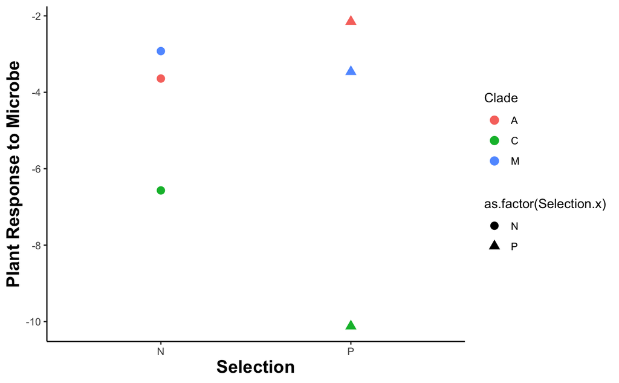

```r
it_5_data_avg  <- it_5_data %>%
  group_by(Selection.x,Clade) %>%
  summarise(avg = mean(Response), n=n(), se = std.error(Response))
ggplot(it_5_data_avg)+
  aes(x = Selection.x, y = avg, color = Clade)+
  scale_x_discrete(name = "Selection")+
  scale_y_continuous(name = "Plant Response to Microbe")+
   geom_point(aes(shape=as.factor(Selection.x)), size=3)+
  theme_classic()+
  theme(axis.title.x = element_text(face="bold", size=15))+
  theme(axis.title.y = element_text(face="bold", size=15))
```

for modern potatoes: **Use as Figure 1A Ch 3**

[figure not shown]

For Chiletanum potatoes: **Use as Figure 1B Ch 3**

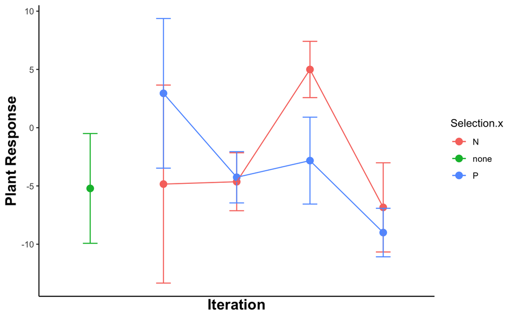

```r
metadata_C <- subset(metadata3, Response != "NA" & Clade == "C" & Soil_type.x != "Sterile")

metadata_C_avg  <- metadata_C %>%
  group_by(Selection.x,Iteration,Soil_type.x) %>%
  summarise(avg = mean(Response), n=n(), se = std.error(Response))
metadata_C_avg  = unite(metadata_C_avg  , combo_line, c("Soil_type.x","Selection.x"), remove = F)

metadata_C_avg = subset(metadata_C_avg, Soil_type.x != "Winterfell")


ggplot(metadata_C_avg)+
  aes(x = Iteration, y = avg, color = Selection.x)+
  scale_x_discrete(name = "Iteration")+
  scale_y_continuous(name = "Plant Response")+
   geom_point(aes(color=Selection.x), size=3)+
  geom_errorbar(aes(ymin=avg-se, ymax=avg+se), width=.2)+
  geom_line(aes(color=Selection.x))+
  theme_classic()+
  theme(axis.title.x = element_text(face="bold", size=15))+
  theme(axis.title.y = element_text(face="bold", size=15))
```

```r
metadata_C <- subset(metadata3, Response != "NA" & Clade == "C" & Soil_type.x != "Sterile")

Clade_C_res <- lmer(Response ~ Soil_type.x*Selection.x*Iteration+ (1|Genotype) + (1|Block), data = metadata_C)
```

```
fixed-effect model matrix is rank deficient so dropping 2 columns / coefficients
```

```r
anova(Clade_C_res)
```

```
Type III Analysis of Variance Table with Satterthwaite's method
                                   Sum Sq Mean Sq NumDF   DenDF F value  Pr(>F)
Soil_type.x                        153.51  153.51     1  14.153  0.8447 0.37345
Selection.x                        809.39  404.70     2 189.609  2.2269 0.11067
Iteration                         1519.66 1519.66     1 189.068  8.3623 0.00428 **
Soil_type.x:Selection.x             68.24   34.12     2 189.917  0.1877 0.82898
Soil_type.x:Iteration              234.19  234.19     1 189.068  1.2887 0.25773
Selection.x:Iteration              469.53  469.53     1 189.077  2.5837 0.10964
Soil_type.x:Selection.x:Iteration   57.78   57.78     1 189.077  0.3179 0.57353
---
Signif. codes:  0 ‘***’ 0.001 ‘**’ 0.01 ‘*’ 0.05 ‘.’ 0.1 ‘ ’ 1
```

For andigenum potatoes: **Use as Figure 1C Ch 3**

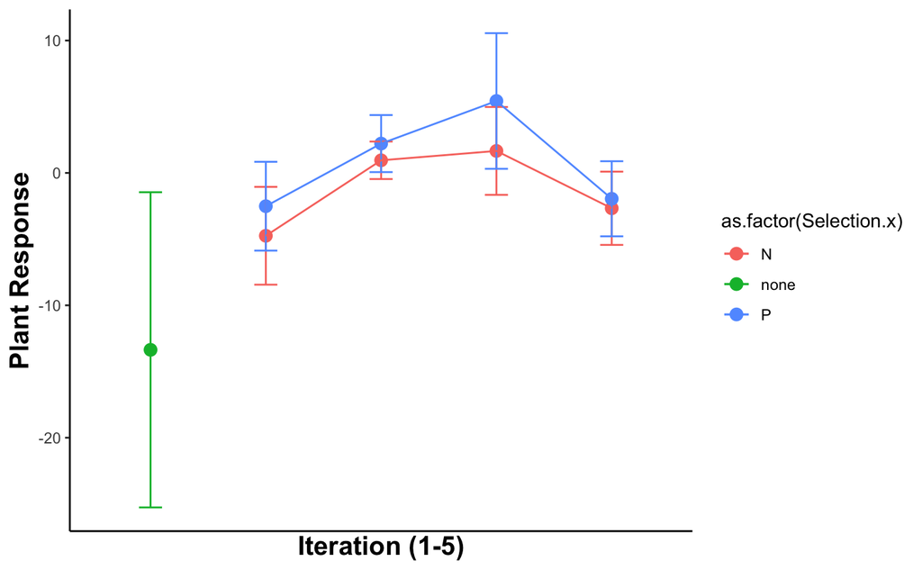

```r
metadata_A <- subset(metadata3, Response != "NA" & Clade == "A" & Soil_type.x != "Sterile")

metadata_A_avg  <- metadata_A %>%
  group_by(Selection.x,Iteration,Soil_type.x) %>%
  summarise(avg = mean(Response), n=n(), se = std.error(Response))
metadata_A_avg  = unite(metadata_A_avg  , combo_line, c("Soil_type.x","Selection.x"), remove = F)

metadata_A_avg = subset(metadata_A_avg, Soil_type.x != "Winterfell")

ggplot(metadata_A_avg)+
  aes(x = Iteration, y = avg, color = as.factor(Selection.x))+
  scale_x_discrete(name = "Iteration (1-5)")+
  scale_y_continuous(name = "Plant Response")+
  geom_point(aes(color=Selection.x), size=3)+
  geom_errorbar(aes(ymin=avg-se, ymax=avg+se), width=.2)+
  geom_line(aes(color=Selection.x))+
  theme_classic()+
  theme(axis.title.x = element_text(face="bold", size=15))+
  theme(axis.title.y = element_text(face="bold", size=15))
```

```r
metadata_A <- subset(metadata3, Response != "NA" & Clade == "M" & Soil_type.x != "Sterile")

Clade_A_res <- lmer(Response ~ Soil_type.x*Selection.x* + (1|Genotype) + (1|Block), data = metadata_A)

anova(Clade_A_res)
```

#winterfell soils:

[figure not shown]

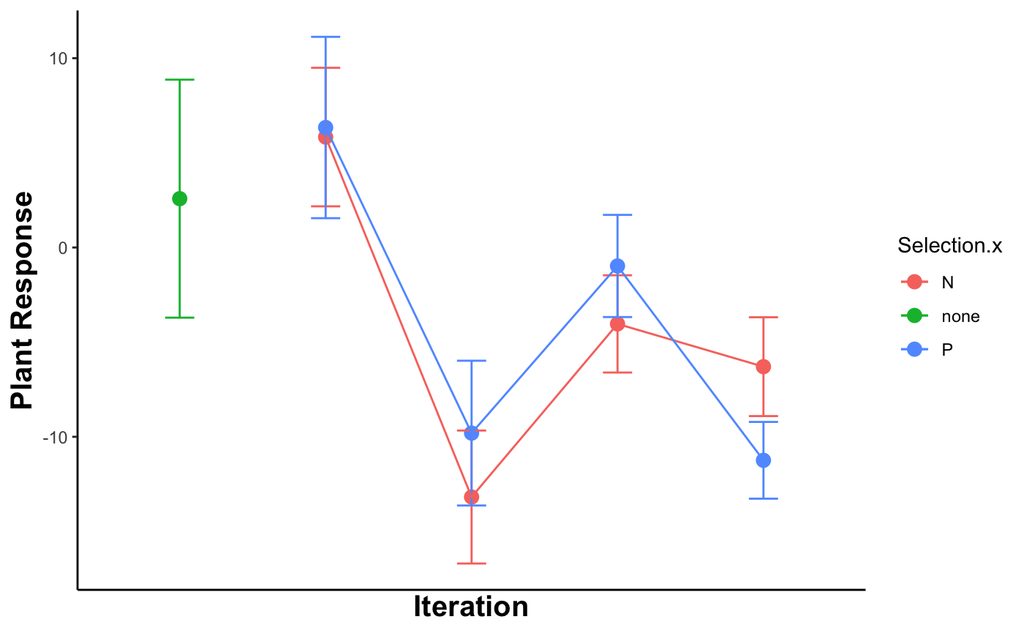

```r
metadata_C <- subset(metadata3, Response != "NA" & Clade == "C" & Soil_type.x != "Sterile")

metadata_C_avg  <- metadata_C %>%
  group_by(Selection.x,Iteration,Soil_type.x) %>%
  summarise(avg = mean(Response), n=n(), se = std.error(Response))
metadata_C_avg  = unite(metadata_C_avg  , combo_line, c("Soil_type.x","Selection.x"), remove = F)

metadata_C_avg = subset(metadata_C_avg, Soil_type.x == "Winterfell")

ggplot(metadata_C_avg)+
  aes(x = Iteration, y = avg, color = Selection.x)+
  scale_x_discrete(name = "Iteration")+
  scale_y_continuous(name = "Plant Response")+
   geom_point(aes(color=Selection.x), size=3)+
  geom_errorbar(aes(ymin=avg-se, ymax=avg+se), width=.2)+
  geom_line(aes(color=Selection.x))+
  theme_classic()+
  theme(axis.title.x = element_text(face="bold", size=15))+
  theme(axis.title.y = element_text(face="bold", size=15))
```

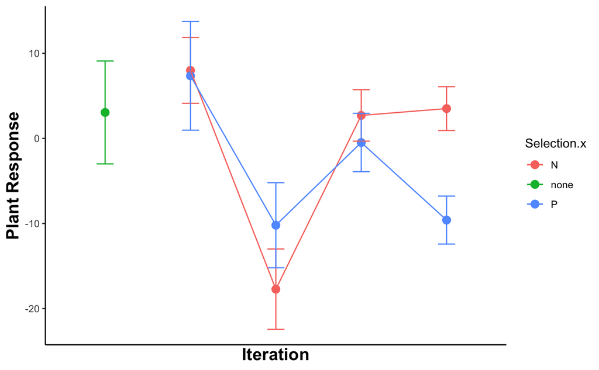

```r
metadata_M <- subset(metadata3, Response != "NA" & Clade == "M" & Soil_type.x != "Sterile")

metadata_M_avg  <- metadata_M %>%
  group_by(Selection.x,Iteration,Soil_type.x) %>%
  summarise(avg = mean(Response), n=n(), se = std.error(Response))
metadata_M_avg  = unite(metadata_M_avg  , combo_line, c("Soil_type.x","Selection.x"), remove = F)

metadata_M_avg = subset(metadata_M_avg, Soil_type.x == "Winterfell")

ggplot(metadata_M_avg)+
  aes(x = Iteration, y = avg, color = Selection.x)+
  scale_x_discrete(name = "Iteration")+
  scale_y_continuous(name = "Plant Response")+
   geom_point(aes(color=Selection.x), size=3)+
  geom_errorbar(aes(ymin=avg-se, ymax=avg+se), width=.2)+
  geom_line(aes(color=Selection.x))+
  theme_classic()+
  theme(axis.title.x = element_text(face="bold", size=15))+
  theme(axis.title.y = element_text(face="bold", size=15))
```

*Musings*

Why this may have manifested where A) see microbiomes are not co-localizing based on selection (except for iterations 3) and B) see response to microbes (aka PMR) is explained soil_type and selection.

Scenario 1) Enriching for microbes that are commensals that are not pathogenic to the plant, commensals are host specific but do not lead to qualitative plant response…

Scenario 2) Same microbes that lead to increased plant growth is small portion of the microbial community and due to environmental manipulations vary. These PGPB are not host specific at the sub-species level. Due to chance, manipulations may have depleted them due to stochasticity aka selection sweeps/soil_type (sort of like genetic drift)

Scenario 3) Maybe enriching for microbial communities that are doing some sort of off target functional effect that we are not capturing thru measurement of tubermass. Maybe need to look at other plant metrics (dry biomass)…

Regardless, we do see that soil_type does play a role in plant response so the environment that the microbes live in do make a difference….